# Exercise #3

Fortgeschrittene Statistische Software für NF

Maximilian Dietz (12128551)  
2025-06-06

## General Remarks

- You can submit your solutions in teams of up to 3 students.
- Include all your team-member’s names and student numbers (Matrikelnummern) in the `authors` field.
- Please use the exercise template document to work on and submit your results.
- Use a level 2 heading for each new exercise and answer each subtask next to its bullet points or use a new level 3 heading if you want.
- Always render the R code for your solutions (`echo=TRUE`) and make sure to include the resulting data in your rendered document.
  - Make sure to not print more than 10 rows of data (unless specifically instructed to).
- Always submit both the rendered document(s) as well as your source Rmarkdown or Quarto document. Submit the files separately on moodle, **not** as a zip archive.
- Submission format is HTML. Other formats will lead to a deduction of points.

## Exercise 1: Initializing git (4 Points)

For this whole exercise sheet we will be tracking all our changes to it in git.

1. Start by initializing a new R project with git support, called `2025-exeRcise-sheet-3`. If you forgot how to do this, you can follow this [guide](https://malikaihle.github.io/Introduction-RStudio-Git-GitHub/rstudio_project.html).
2. Commit the files generated by Rstudio.
3. For all of the following tasks in this exercise sheet we ask you to always commit your changes after finishing each subtask e.g. create a commit after task *1d*, *1e* etc.

> Note: This applies only to answers that have text or code as their answer. If you complete tasks in a different order or forget to commit one, this is no problem. If you change your answers you can just create multiple commits to track the changes.
4. Name 2 strengths and 2 weaknesses of git. (Don’t forget to create a commit after this answer, see *1c*)

   Strenght:
   - Very hard to lose files with git
   - Great for collaboration

   Weaknesses:
   - Can be a bit complicated to use
   - History takes up file space
5. Knit this exercise sheet. Some new files will automatically be generated when knitting the sheet e.g. the HTML page. Ignore these files, as we only want to track the source files themselves. You can, but don’t need to create a `.gitignore` file. Just do not commit these files manually.

## Exercise 2: Putting your Repository on GitHub (3 Points)

For this task you will upload your solution to GitHub.

1. Create a new repository on GitHub in your account named `exeRcise-sheet-3`. Make sure you create a **public repository** so we are able to see it for grading. Add the link to the repository below:

   https://github.com/TheBlackPulsar/2025-exeRcise-sheet-3
2. Push your code to this new repository by copying and executing the snippet on github listed under `…or push an existing repository from the command line`.
3. Regularly push your latest changes to GitHub again and especially do so when you are finished with this sheet.

## Exercise 3: Pixar Films (4 Points)

Download the `pixar_films` and `public_response` datasets from the GitHub repository and track them in git.

Link: https://github.com/rfordatascience/tidytuesday/tree/main/data/2025/2025-03-11

For small datasets like these adding them to git is not a problem.

1. Load the `pixar_films` dataset into R. Clean the dataset by removing films without a title. Inspect the variable `film_rating`. What are the possible values and what do they mean? Create a factor variable for the film rating. Why is this appropriate?

```r
knitr::opts_chunk$set(echo = TRUE)
library(tidyverse)
library(lubridate)
library(readr)
```

```r
pixar_films <- read_csv("pixar_films.csv")

pixar_films <- pixar_films %>%
  filter(!is.na(title))

pixar_films <- pixar_films %>%
  mutate(
    film_rating = factor(
      film_rating,
      levels = c("G", "PG", "PG-13", "R", "NC-17"),
      ordered = TRUE
    )
  )

pixar_films %>%
  arrange(film_rating) %>%
    head(10)
```

```
# A tibble: 10 × 5
   number film           release_date run_time film_rating
    <dbl> <chr>          <date>          <dbl> <ord>
 1      1 Toy Story      1995-11-22         81 G
 2      2 A Bug's Life   1998-11-25         95 G
 3      3 Toy Story 2    1999-11-24         92 G
 4      4 Monsters, Inc. 2001-11-02         92 G
 5      5 Finding Nemo   2003-05-30        100 G
 6      7 Cars           2006-06-09        117 G
 7      8 Ratatouille    2007-06-29        111 G
 8      9 WALL-E         2008-06-27         98 G
 9     11 Toy Story 3    2010-06-18        103 G
10     12 Cars 2         2011-06-24        106 G
```

The characters found in the `film_rating` section of the pixar_films.csv show the Motion Picture Associations rating of the films by their film rating system. The G that we can see for example stands for general audience - All ages admitted while the PG stand for Pranetal guidance suggested - Some material may not be suitable for children.

The `film_rating` variable is a categorical variable that tells if a film is save for children or has a risk to watch it with children. In case of this categorical variable it is appropriate to create a factor that tells the order of the rakings from save for children to not save for children as you can see above.

2. Inspect the film titles manually. Which films form a film series? A film series can be identified by a common word in the titles of the films, often in conjunction with a number in the title, e.g. “Despicable Me” and “Despicable Me 2”. Create a dataframe which displays a list of the different series with the titles of the films and how many films belong to the series. Output the dataframe.

```r
series_candidates <- pixar_films %>%
  filter(str_detect(film, "Toy Story|Monsters|Finding|Incredibles|Cars")) %>%
  mutate(series = case_when(
    str_detect(film, "Toy Story") ~ "Toy Story",
    str_detect(film, "Monsters") ~ "Monsters",
    str_detect(film, "Finding") ~ "Finding",
    str_detect(film, "Incredibles") ~ "Incredibles",
    str_detect(film, "Cars") ~ "Cars",
    TRUE ~ "Other"
  ))

series_summary <- series_candidates %>%
  group_by(series) %>%
  summarise(
    films = paste(film, collapse = "; "),
    n = n()
  )

series_summary
```

```
# A tibble: 5 × 3
  series      films                                                n
  <chr>       <chr>                                            <int>
1 Cars        Cars; Cars 2; Cars 3                                 3
2 Finding     Finding Nemo; Finding Dory                           2
3 Incredibles The Incredibles; Incredibles 2                       2
4 Monsters    Monsters, Inc.; Monsters University                  2
5 Toy Story   Toy Story; Toy Story 2; Toy Story 3; Toy Story 4     4
```

3. Load the `public_response` dataframe into R. Convert the `cinema_score` variable into a factor while ensuring the factor levels are defined in ascending order, from the lowest to the highest score. Combine `public_response` with the `pixar_films` dataset using an appropriate merge variable.

```r
public_response <- read_csv("public_response.csv")

public_response <- public_response %>%
  mutate(cinema_score = factor(cinema_score,
                               levels = c("A+", "A", "A-", "B", "C", "D", "F"),
                               ordered = TRUE))

pixar_joined <- pixar_films %>%
  left_join(public_response, by = "film")

pixar_joined %>%
  arrange(cinema_score) %>%
    select(film, cinema_score, everything()) %>%
      head(10)
```

```
# A tibble: 10 × 9
   film          cinema_score number release_date run_time film_rating
   <chr>         <ord>         <dbl> <date>          <dbl> <ord>
 1 Toy Story 2   A+                3 1999-11-24         92 G
 2 Monsters, In… A+                4 2001-11-02         92 G
 3 Finding Nemo  A+                5 2003-05-30        100 G
 4 The Incredib… A+                6 2004-11-05        115 PG
 5 Up            A+               10 2009-05-29         96 PG
 6 Coco          A+               19 2017-11-22        105 PG
 7 Incredibles 2 A+               20 2018-06-15        118 PG
 8 Toy Story     A                 1 1995-11-22         81 G
 9 A Bug's Life  A                 2 1998-11-25         95 G
10 Cars          A                 7 2006-06-09        117 G
# ℹ 3 more variables: rotten_tomatoes <dbl>, metacritic <dbl>,
#   critics_choice <dbl>
```

4. Choose one of the variables representing the public response and create a bar plot for the films belonging to a series. Here are the details of the plot:
   - The film series are represented on the x-axis.
   - Your chosen public response variable is displayed on the y-axis.
   - Each film in the series is represented as a separate bar. Bars are grouped by film under their respective series on the x-axis. Order the bars within a series according to the release date of the films.
   - A title and axis labels for context.

   What do you notice when comparing the scores of the films in a series? Do you see any patterns?

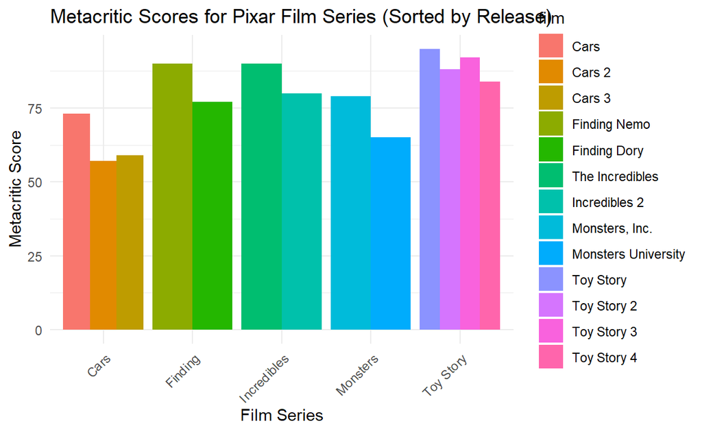

```r
pixar_series <- series_candidates %>%
  left_join(public_response, by = "film") %>%
  group_by(series, film) %>%
  summarise(
    metacritic = mean(metacritic, na.rm = TRUE),
    release_date = first(release_date),
    .groups = "drop"
  ) %>%
  arrange(series, release_date) %>%
  group_by(series) %>%
  mutate(film = factor(film, levels = film))

ggplot(pixar_series, aes(x = series, y = metacritic, fill = film)) +
  geom_bar(stat = "identity", position = position_dodge(width = 0.9)) +
  labs(
    title = "Metacritic Scores for Pixar Film Series (Sorted by Release)",
    x = "Film Series",
    y = "Metacritic Score"
  ) +
  theme_minimal() +
  theme(axis.text.x = element_text(angle = 45, hjust = 1))
```

The first film of each series was the one with the best metacritic score. In the case of cars and toy story we could also assume that the third one is always better as the second one that was lower than the first but this woeuld only be a hypothesis that is not proofed by only two exapmles.

## Exercise 4: Open Analysis (4 points)

This exercise is a bit more open-ended. You can choose any dataset from [Our World in Data](https://ourworldindata.org/) and analyze it, while determining the research question yourself.

1. Go to https://github.com/owid/owid-datasets/tree/master/datasets and choose a dataset that interests you. You can have a look at https://ourworldindata.org/ to gather some inspiration.
2. Download the dataset and track it in git.
3. Put the name / title of the dataset and a link to it below.
- Dataset Name: Sex ratio by age (OWID based on UNWPP, 2017)
- Link: https://github.com/owid/owid-datasets/tree/master/datasets/Sex%20ratio%20by%20age%20(OWID%20based%20on%20UNWPP%2C%202017)
4. Come up with a (research) question you want to answer with the data and briefly explain why you believe this is an interesting question within one sentence. It should be a question that can be answered with the dataset and using R.

How did the sex ratio by age change between 1970 and 1999? I think this is interesting to me because I want to take a look how the sex ratio by age changed between the birth year of my father and mine.

5. Use R to answer your chosen question. Please limit your analysis to the functions and techniques we have covered so far in the course. You are **not expected** to use advanced statistical models or external packages which haven’t been introduced.

```r
sex_ratio <- read_csv("Sex ratio by age (OWID based on UNWPP, 2017).csv")

str(sex_ratio)
```

```
spc_tbl_ [15,906 × 15] (S3: spec_tbl_df/tbl_df/tbl/data.frame)
 $ Entity                           : chr [1:15906] "Afghanistan" "Afghanistan" "Afghanistan" "Afghanistan" ...
 $ Year                             : num [1:15906] 1950 1951 1952 1953 1954 ...
 $ Sex ratio by age (one-year olds) : num [1:15906] 93 91 101 103 105 ...
 $ Sex ratio by age (five-year olds): num [1:15906] 103.1 100.6 97.6 95.1 93.7 ...
 $ Sex ratio by age (10 year olds)  : num [1:15906] 109 109 108 107 105 ...
 $ Sex ratio by age (15 year olds)  : num [1:15906] 111 110 109 109 109 ...
 $ Sex ratio by age (20 year olds)  : num [1:15906] 116 114 113 111 111 ...
 $ Sex ratio by age (30 year olds)  : num [1:15906] 119 118 118 117 117 ...
 $ Sex ratio by age (40 year olds)  : num [1:15906] 120 119 119 118 118 ...
 $ Sex ratio by age (50 year olds)  : num [1:15906] 125 125 124 122 120 ...
 $ Sex ratio by age (60 year olds)  : num [1:15906] 130 130 129 128 125 ...
 $ Sex ratio by age (70 year olds)  : num [1:15906] 130 129 128 127 125 ...
 $ Sex ratio by age (80 year olds)  : num [1:15906] NA NA NA NA NA NA NA NA NA NA ...
 $ Sex ratio by age (90 year olds)  : num [1:15906] NA NA NA NA NA NA NA NA NA NA ...
 $ Sex ratio by age (100 year olds) : num [1:15906] NA NA NA NA NA NA NA NA NA NA ...
 - attr(*, "spec")=
  .. cols(
  ..   Entity = col_character(),
  ..   Year = col_double(),
  ..   `Sex ratio by age (one-year olds)` = col_double(),
  ..   `Sex ratio by age (five-year olds)` = col_double(),
  ..   `Sex ratio by age (10 year olds)` = col_double(),
  ..   `Sex ratio by age (15 year olds)` = col_double(),
  ..   `Sex ratio by age (20 year olds)` = col_double(),
  ..   `Sex ratio by age (30 year olds)` = col_double(),
  ..   `Sex ratio by age (40 year olds)` = col_double(),
  ..   `Sex ratio by age (50 year olds)` = col_double(),
  ..   `Sex ratio by age (60 year olds)` = col_double(),
  ..   `Sex ratio by age (70 year olds)` = col_double(),
  ..   `Sex ratio by age (80 year olds)` = col_double(),
  ..   `Sex ratio by age (90 year olds)` = col_double(),
  ..   `Sex ratio by age (100 year olds)` = col_double()
  .. )
 - attr(*, "problems")=<externalptr>
```

```r
germany <- sex_ratio %>%
  filter(Entity == "Germany", Year %in% c(1970, 1999))

germany_long <- germany %>%
  pivot_longer(
    cols = starts_with("Sex ratio by age"),
    names_to = "age_group",
    values_to = "sex_ratio"
  )

germany_long <- germany_long %>%
  mutate(
    Age = parse_number(age_group),
    Age = case_when(
      is.na(Age) & age_group == "Sex ratio by age (one-year olds)" ~ 1,
      is.na(Age) & age_group == "Sex ratio by age (five-year olds)" ~ 5,
      TRUE ~ Age
    )
  ) %>%
  select(Year, Age, sex_ratio)

germany_long %>%
  group_by(Year) %>%
  summarise(mean_ratio = mean(sex_ratio, na.rm = TRUE))
```

```
# A tibble: 2 × 2
   Year mean_ratio
  <dbl>      <dbl>
1  1970       94.3
2  1999       84.8
```

```r
germany_long <- germany_long %>%
  mutate(age_group = case_when(
    Age <= 19 ~ "Young",
    Age <= 64 ~ "Adult",
    Age > 64  ~ "Old"
  ))

germany_long %>%
  group_by(Year, age_group) %>%
  summarise(mean_ratio = mean(sex_ratio, na.rm = TRUE))
```

```
# A tibble: 6 × 3
# Groups:   Year [2]
   Year age_group mean_ratio
  <dbl> <chr>          <dbl>
1  1970 Adult           91.5
2  1970 Old             66.2
3  1970 Young          105.
4  1999 Adult          102.
5  1999 Old             42.4
6  1999 Young          105.
```

```r
diff_table <- germany_long %>%
  pivot_wider(names_from = Year, values_from = sex_ratio) %>%
  mutate(difference = `1999` - `1970`)
```

In the grouped_df table we can see that the difference between the young group in 1970 and 1999 is very little and that there was a overload on men with over slightly over 100 men per 100 women. Looking at the adults we had much lesser men then women in the adult section which changend into much more men than women in 1999. In the old section we have much less men than in women in 1970 and even lesser men per 100 women in 1999.

Looking at table tbl_df we can see that there are living much lesser men per women in 1999 than in 1970 which results as seen above from the massive differences especially in the older age.

6. Create a meaningful plot / figure with the dataset. Make sure to provide a figure caption (via the chunk options / Rmarkdown) and correctly label the figure.

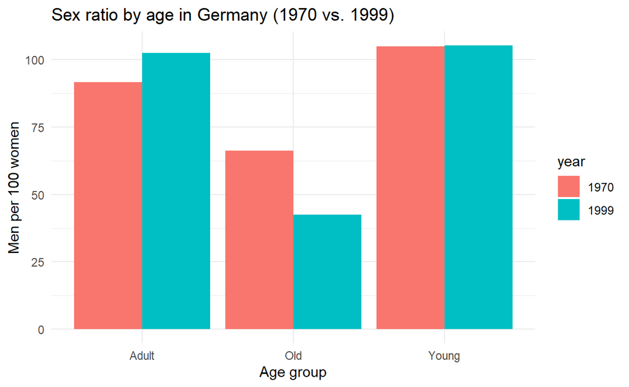

```r
germany_long %>%
  mutate(age_group = case_when(
    Age <= 19 ~ "Young",
    Age <= 64 ~ "Adult",
    Age > 64  ~ "Old"
  )) %>%
  group_by(Year, age_group) %>%
  summarise(mean_ratio = mean(sex_ratio, na.rm = TRUE)) %>%
  ggplot(aes(x = age_group, y = mean_ratio, fill = as.factor(Year))) +
  geom_bar(stat = "identity", position = "dodge") +
  labs(
    title = "Sex ratio by age in Germany (1970 vs. 1999)",
    x = "Age group",
    y = "Men per 100 women",
    fill = "year"
  ) +
  theme_minimal()
```

## Final Note

Make sure to push all your commits and changes to GitHub before submitting the exercise sheet.